# Tree from Eulerian Triangulation

Ryo Yamada

2017年9月15日

# 1 Eulerian Triangulation

The series of triangulation are all Eulerian.

```r
my.partition.tris <- function(tri.x){
    tris <- tri.x$tris
    X <- tri.x$X
    col <- tri.x$col
    tris <- t(apply(tris,1,sort))
    pairs <- rbind(tris[,1:2],tris[,2:3],tris[,c(1,3)])
    pairs2 <- t(apply(pairs,1,sort))
    pairs2 <- unique(pairs)
    new.v <- (1:length(pairs2[,1])) + max(pairs2)
    new.X <- (X[pairs2[,1],] + X[pairs2[,2],] ) /2
    ret.X <- rbind(X,new.X)
    new.tris <- matrix(0,0,3)
    new.col <- c()
    for(i in 1:length(tris[,1])){
        tri.now <- tris[i,]
        tri.add1 <- which(pairs2[,1]==tri.now[1] & pairs2[,2]==tri.now[2])+ max(pairs2)
        tri.add2 <- which(pairs2[,1]==tri.now[2] & pairs2[,2]==tri.now[3])+ max(pairs2)
        tri.add3 <- which(pairs2[,1]==tri.now[1] & pairs2[,2]==tri.now[3])+ max(pairs2)

        tmp <- rbind(c(tri.now[1],tri.add1,tri.add3),c(tri.now[2],tri.add1,tri.add2),c(tri.now[3],tri.add2,tri.add3),c(tri.add1,tri.add2,tri.add3))
        new.tris <- rbind(new.tris,tmp)
        if(col[i]==1){
            tmp.col <- c(2,2,2,1)
        }else{
            tmp.col <- c(1,1,1,2)
        }
        new.col <- c(new.col,tmp.col)
    }
    new.tris <- t(apply(new.tris,1,sort))

    ret.X <- ret.X/sqrt(apply(ret.X^2,1,sum))
    return(list(tris=new.tris,X=ret.X,col=new.col))
}

my.plot.eultri <- function(tri){
    plot3d(tri$X,cex=0.01)
    n.Face <- length(tri$tris[,1])
    col <- rep(2:3,n.Face/2)
    col <- c(rbind(tri$col,tri$col,tri$col))
    tmp.ord <- c(t(tri$tris))
    triangles3d(tri$X[tmp.ord,],col=col+1)
}
```

```r
tris8=matrix(c(1,2,3,1,3,4,1,4,5,1,5,2,2,3,6,3,4,6,4,5,6,5,2,6),byrow=TRUE,ncol=3)
X8 = matrix(c(0,0,1,1,0,0,0,1,0,-1,0,0,0,-1,0,0,0,-1),byrow=TRUE,ncol=3)
col8 = c(1,2,1,2,2,1,2,1)
init.tri.x <- list(tris=tris8,X=X8,col=col8)

n.step <- 3
tri.x.list <- list()
tri.x.list[[1]] <- init.tri.x
for(i in 2:n.step){
    tri.x.list[[i]] <- my.partition.tris(tri.x.list[[i-1]])
}
```

Plot the final triangulation.

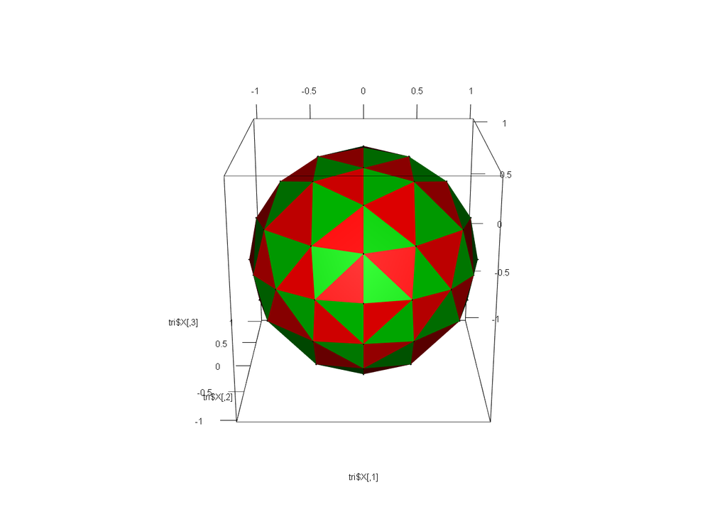

```r
my.plot.eultri(tri.x.list[[n.step]])
```

# 2 Directed graph from Eulerian triangulation

Each edge should be directed such that the black triangle next to the edge should be on its right side.

The orientation can be determined by the sign of “signed-volume” of parallelepiped spanned by three vectors starting at the origin and ending at three vertices.

```r
my.direction.eultri <- function(tri,black=1){
  n.tri <- length(tri$tris[,1])
  n.edge <- n.tri*3/2
  el <- matrix(0,n.edge,2)
  black.tris <- tri$tris[which(tri$col==black),]
  cnt <- 1
  for(i in 1:length(black.tris[,1])){
    v <- black.tris[i,]
    M <- tri$X[v,]
    d <- det(M)
    if(d < 0){
      el[cnt,] <- c(v[1],v[2])
      el[cnt+1,] <- c(v[2],v[3])
      el[cnt+2,] <- c(v[3],v[1])
    }else{
      el[cnt,] <- c(v[2],v[1])
      el[cnt+1,] <- c(v[3],v[2])
      el[cnt+2,] <- c(v[1],v[3])
    }
    cnt <- cnt+3

  }
  return(el)
}
```

Generate a directed graph object.

```r
tri <- tri.x.list[[n.step]]
```

```r
el <- my.direction.eultri(tri,black=1)
```

```r
# black triangles are "col=1". white triangles are "col=2".
#el <- my.direction.eultri(tri.x.list[[1]],black=1)
```

```r
g <- graph.edgelist(el)
#plot(g)
```

Select a root node and calculate graph distance to all nodes from the root.

```r
rho <- sample(1:length(tri$X[,1]),1)
Z <- shortest.paths(g,rho,mode="out")
```

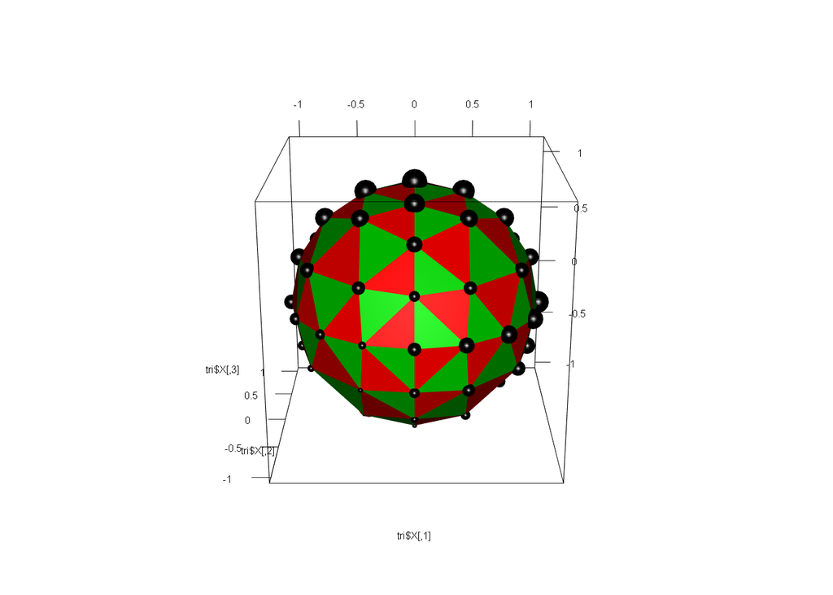

```r
my.plot.eultri(tri)
spheres3d(tri$X,radius=Z*0.01)
spheres3d(tri$X[rho,],radius=0.1,color="red")
```

# 3 Construction of a tree

The tree should be consisted of all nodes of the triangulation and the nodes corresponding to triangles should be added.

The nodes from white triangles are called “unflagged” nodes and they are connected to the nodes in the triangulation.

The nodes from black triangles are called “flagged” nodes and they are connected to the “unflagged nodes” in the way described below.

```r
my.eurtree <- function(tri,rho=1,black=1){
  el <- my.direction.eultri(tri,black)
  g <- graph.edgelist(el)
  Z <- shortest.paths(g,rho,mode="out")
  n.v <- length(tri$X[,1])
  n.f <- length(tri$tris[,1])
  col.lab <- unique(tri$col)
  white <- tri$col[which(col.lab!=black)]

  tmpX <- matrix(tri$X[tri$tris,1],ncol=3)
  tmpY <- matrix(tri$X[tri$tris,2],ncol=3)
  tmpZ <- matrix(tri$X[tri$tris,3],ncol=3)
  new.X <- cbind(apply(tmpX,1,mean),apply(tmpY,1,mean),apply(tmpZ,1,mean))
  white.tri <- which(tri$col==white)
  unfl.v <- which(tri$col==white)
  fl.v <- which(tri$col==black)
  unfl.el <- matrix(0,length(unfl.v)*2,2)
  fl.el <- matrix(0,length(fl.v),2)
  unfl.cnt <- 1
  fl.cnt <- 1
  flgs <- matrix(0,length(fl.v),2)
  for(i in 1:length(white.tri)){
    v <- tri$tris[white.tri[i],]
    v. <- c(v,v)
    for(j in 1:3){
      this.el <- v.[j,j+1]
      this.Z <- Z[this.el]
      m <- Z[1]
      n <- Z[2]
      if(n==m+1){
        # v.id of ctr of white tri is i + n.v
        unfl.el[unfl.cnt,] <- c(i+n.v,this.el[2])
        unfl.cnt <- unfl.cnt + 1
      }else{
        # v.id of ctr of black tri is i + 2 * n.v
        fl.el[fl.cnt,] <- c(i+n.v,i+2*n.v)
        flgs[fl.cnt,] <- this.el
        fl.cnt <- fl.cnt + 1
      }
    }
  }
  ret.X <- rbind(tri$X,new.X[white.tri,],new.X[!white.tri,])
  ret.el <- rbind(el,unfl.el,fl.el)
  ret.g <- graph.edgelist(ret.el)
  # flgs
  return(list(g=ret.g,el=ret.el,X=ret.X,flgs=flgs,flg.v=(2*n.v+1):length(ret.X[,1]),flg.e = (length(ret.el[,1])-length(fl.v)+1):length(ret.el[,1])))

}
```